# Modeling and Optimization

Introduction to Linear Programming

Sebastian Souyris

MGMT 6460 Fall 2026

## Roadmap

1. Introduction
2. Prototype Example: Wyndor Glass Co.
3. The Linear Programming Model
4. Assumptions of Linear Programming
5. Additional Example: Radiation Therapy
6. LP on a Spreadsheet: Excel Solver
7. Large Models and the Modern Workflow
8. Conclusions

# Introduction

## What Is Linear Programming?

**Linear Programming (LP)**

Planning activities to allocate **limited resources** among **competing activities** in the best possible way, using a model built entirely from **linear** functions.

- “Programming” means *planning*; the word predates computer code
- Among the most widely used tools of operations research: production, logistics, finance, marketing, healthcare, energy

**This week**

Today: formulation, graphs, Excel. Next: the simplex method.

# Prototype Example: Wyndor Glass Co.

## The Wyndor Glass Co.

- Produces high-quality windows and glass doors
- Three plants, each with a specialty:
  - **Plant 1**: aluminum frames and hardware
  - **Plant 2**: wood frames
  - **Plant 3**: glass production and assembly
- Management is discontinuing some unprofitable products, freeing capacity for two new ones

**The two candidates**

**Product 1**: 8-ft glass door with aluminum frame (Plants 1 and 3).  
**Product 2**: 4×6-ft double-hung wood-framed window (Plants 2 and 3).

## The Wyndor Problem in One Picture

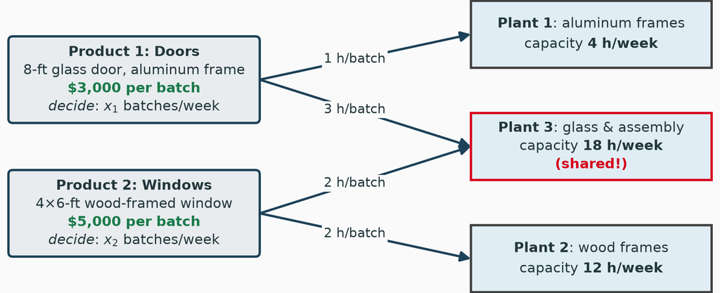

The two products compete only at Plant 3: that is where the tradeoff, and the interesting decision, lives.

## One Decision, Three Scarce Resources

**Question**

What mix of the two products would be most profitable, given the production capacity left in each plant?

- Marketing: the company can sell as much of either product as it can produce
- Production runs in **batches of 20** units; the decision is the number of batches per week
- Data needed:
  - Hours of production time *available* per week in each plant
  - Hours *used* in each plant per batch of each product
  - *Profit* per batch of each product

## The Data

Hours of production time per batch of each product

| Plant | Doors | Windows | Hours available per week |
| --- | --- | --- | --- |
| Plant 1 | 1 | 0 | 4 |
| Plant 2 | 0 | 2 | 12 |
| Plant 3 | 3 | 2 | 18 |
| **Profit per batch** | **$3,000** | **$5,000** |  |

**Read the table as a model waiting to happen**

Each **row** is a scarce resource. Each **column** is an activity competing for it. The last row prices the activities.

## From Data to Decision Model

**Decisions.** Let $x_1$ = batches of doors per week and $x_2$ = batches of windows per week.

**Objective.** Weekly profit in thousands of dollars: maximize $Z = 3x_1 + 5x_2$.

**Constraints.** Weekly hours are limited, and production is nonnegative:

$$\begin{aligned}
\text{Plant 1:} \quad & x_1 \le 4 \\
\text{Plant 2:} \quad & 2x_2 \le 12 \\
\text{Plant 3:} \quad & 3x_1 + 2x_2 \le 18 \\
& x_1 \ge 0, \; x_2 \ge 0
\end{aligned}$$

## The Wyndor Model

**Wyndor LP model**

$$\begin{aligned}
\max~ Z = 3x_1 &+ 5x_2 \\
\text{subject to} \quad
x_1 \phantom{{}+2x_2} &\le 4 \\
2x_2 &\le 12 \\
3x_1 + 2x_2 &\le 18 \\
x_1 \ge 0, \quad x_2 &\ge 0
\end{aligned}$$

- Two decision variables: we can *see* this model in a graph
- Real models have thousands of variables; the geometry generalizes

## Graphical Solution: The Feasible Region

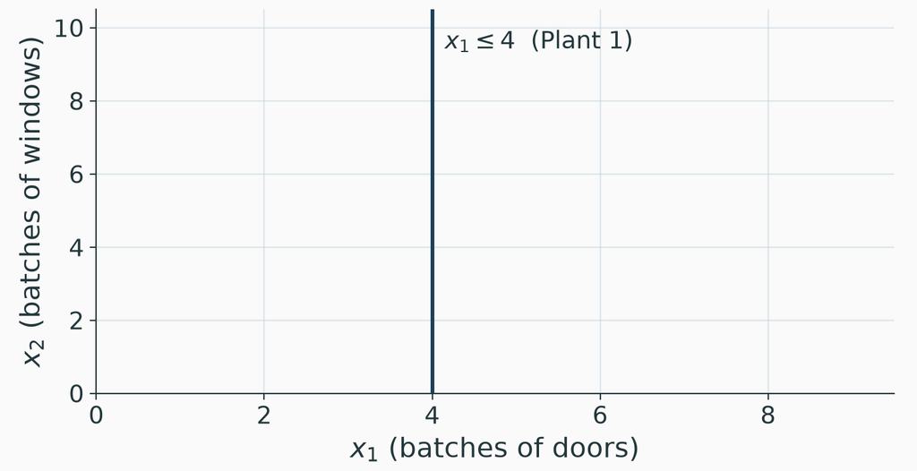

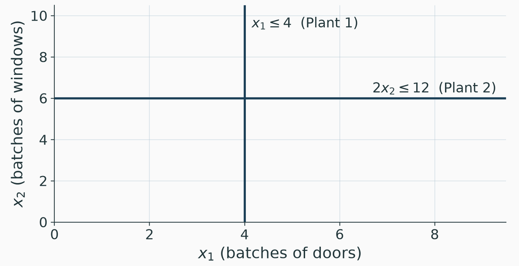

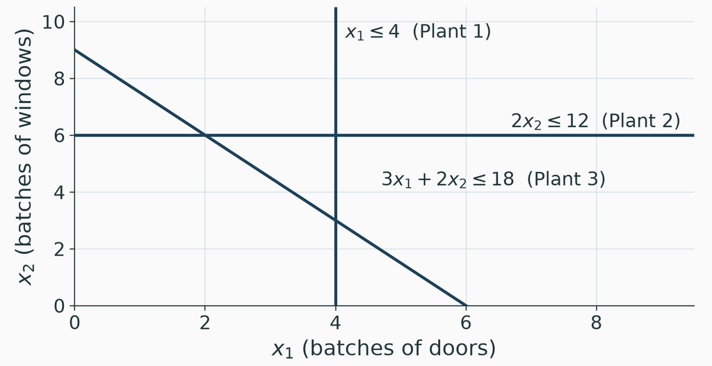

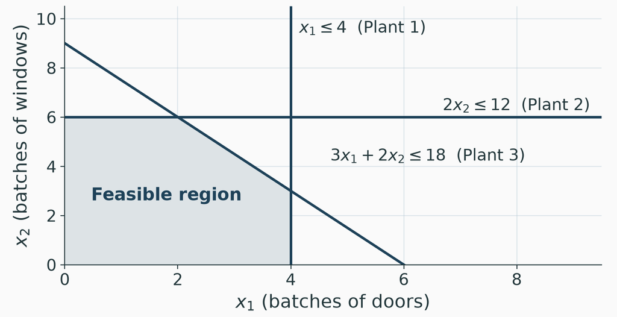

## Graphical Solution: Finding the Optimum

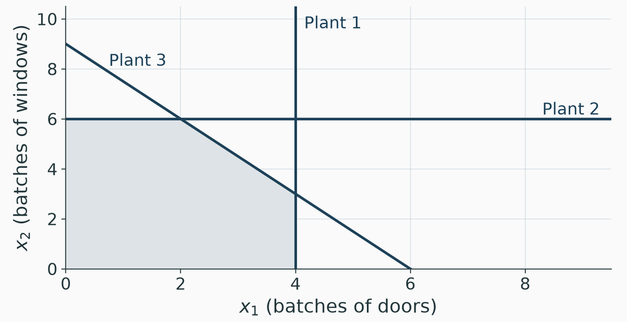

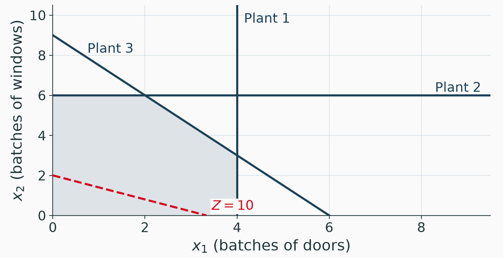

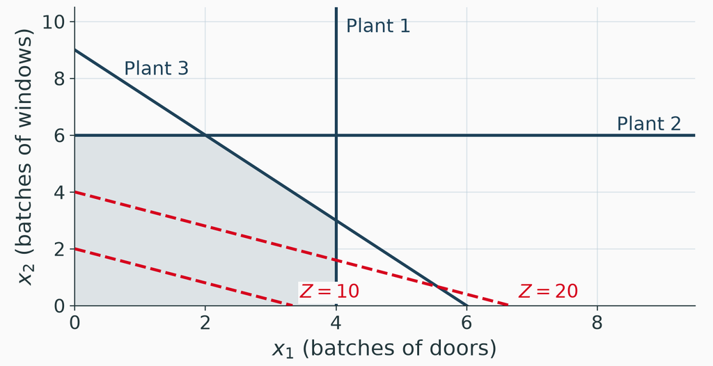

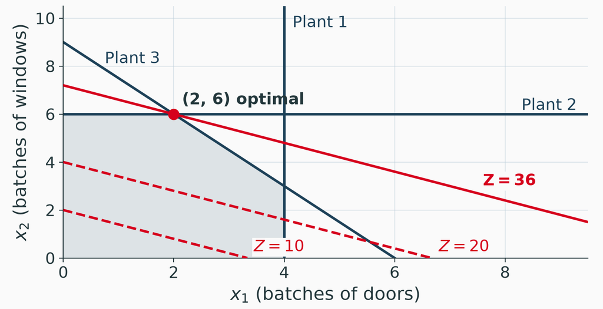

## The Optimal Product Mix

**Wyndor’s answer**

Produce **2 batches of doors** and **6 of windows** per week: $Z = 3(2) + 5(6) = 36$, i.e., **$36,000 per week**. Plants 2 and 3 run at capacity; Plant 1 has 2 idle hours.

- The optimum sits at a *corner* of the feasible region, where the Plant 2 and Plant 3 constraints intersect

**Why we need an algorithm**

The graph works for two variables. For two thousand, we need algebra that visits corners systematically: the **simplex method**, coming next.

# The Linear Programming Model

## From Prototype to General Terminology

| Prototype Example | General Problem |
| --- | --- |
| Production capacities of 3 plants | $m$ resources |
| Production of 2 products | $n$ activities |
| Production rate of product $j$: $x_j$ | Level of activity $j$: $x_j$ |
| Profit $Z$ | Overall performance measure $Z$ |

- **Resources**: money, machine time, vehicles, personnel, budgets
- **Activities**: investing in projects, advertising in media, shipping from a source
- The model chooses activity levels that maximize performance subject to resource limits

## Canonical Form

**LP canonical form**

$$\begin{aligned}
\max~ Z = c_1 x_1 + c_2 x_2 &+ \cdots + c_n x_n \\
\text{subject to} \quad
a_{11}x_1 + a_{12}x_2 &+ \cdots + a_{1n}x_n \le b_1 \\[-2pt]
&\;\;\vdots \\[-2pt]
a_{m1}x_1 + a_{m2}x_2 &+ \cdots + a_{mn}x_n \le b_m \\
x_j &\ge 0, \quad j = 1, \dots, n
\end{aligned}$$

- $c_j$: performance contribution per unit of activity $j$
- $b_i$: amount of resource $i$ available
- $a_{ij}$: resource $i$ consumed per unit of activity $j$

## Other Legitimate Forms

Still linear programming, and all convertible to canonical form:

- **Minimize** instead of maximize: $\min Z = c_1 x_1 + \cdots + c_n x_n$
- Constraints with $\ge$: $\quad a_{i1}x_1 + \cdots + a_{in}x_n \ge b_i$
- Constraints with $=$: $\quad a_{i1}x_1 + \cdots + a_{in}x_n = b_i$
- Variables **unrestricted in sign**: $x_j \in \R$

**Coming right up**

The radiation therapy example uses all three: minimization, a $\ge$ constraint, and an $=$ constraint.

## Types of Solutions

- **Feasible solution**: satisfies *all* constraints
- **Infeasible solution**: violates at least one constraint
- **Feasible region**: the set of all feasible solutions; may be empty (an *infeasible problem*)
- **Optimal solution**: the most favorable objective value among feasible solutions
  - Multiple optima can exist (an entire edge of the region)
  - No optimum exists if the problem is infeasible or the objective is *unbounded* over the region

## Vertices of the Feasible Region

**Vertex (extreme point)**

A feasible solution at a **corner** of the feasible region: it does not lie between two other feasible solutions. Wyndor has five: $(0,0)$, $(4,0)$, $(4,3)$, $(2,6)$, $(0,6)$.

- If a problem has feasible solutions and a bounded region, it has vertices and at least one optimal solution
- **The best vertex must be optimal**

**Why this matters**

An infinite search space collapses to finitely many corners. The simplex method walks from corner to better corner; this property is its engine.

# Assumptions of Linear Programming

## Assumptions I: Proportionality and Additivity

**Proportionality**

Each activity’s contribution to the objective (and to each constraint’s left-hand side) is **proportional** to its level $x_j$. No setup costs, no economies of scale. If violated: nonlinear programming (later this course).

**Additivity**

Every function is the **sum** of individual contributions. No interaction terms: doors do not make windows more profitable.

## Assumptions II: Divisibility and Certainty

**Divisibility**

Decision variables may take **any** values, including fractions. If activities come in indivisible units: integer programming (later this course).

**Certainty**

Every parameter ($c_j$, $a_{ij}$, $b_i$) is a **known constant**.

**Reality check**

Parameters are forecasts, and certainty is seldom exact. Follow every LP solution with **sensitivity analysis**.

# Additional Example: Radiation Therapy

## Designing Radiation Therapy for Mary

- Mary has been diagnosed with cancer; treatment uses external beams
- Radiation weakens healthy cells along the beam path, and healthy tissue absorbs dose as well
- **Goal**: choose beam intensities that deliver the prescribed dose to the tumor while *minimizing* the dose absorbed by healthy anatomy
- Dose is measured in kilorads; two candidate beams, intensities $x_1$ and $x_2$

**A different model shape**

Wyndor allocated resources. Here we buy a required *benefit* (tumor dose) at minimum *cost* (collateral dose): a cost-benefit tradeoff problem.

## Mary’s Treatment

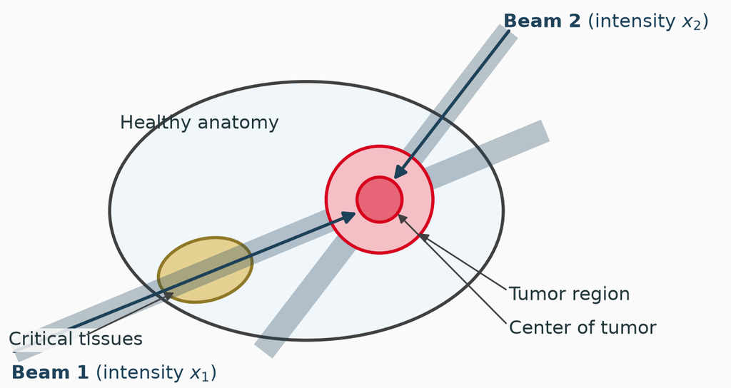

Each beam deposits dose along its entire path: choose $x_1, x_2$ to meet the tumor prescription while sparing the rest.

## What a Real Treatment Plan Looks Like

[figure not shown]

Image: Taheri-Kadkhoda et al., *Radiation Oncology* 2008, 3:4, Fig. 2 (cropped), [CC BY 2.0](https://creativecommons.org/licenses/by/2.0/), via Wikimedia Commons.

- Axial CT slice with the computed dose wash: warm colors are high dose, concentrated on the tumor; contours mark targets and critical structures
- Modern IMRT chooses *thousands* of beamlet intensities: Mary’s model at industrial scale

**Same model shape**

Minimize collateral dose, subject to prescription constraints.

## The Dose Data

Fraction of entry dose absorbed by each area (average)

| Area | Beam 1 | Beam 2 | Restriction (kilorads) |
| --- | --- | --- | --- |
| Healthy anatomy | 0.4 | 0.5 | minimize |
| Critical tissues | 0.3 | 0.1 | $\le 2.7$ |
| Tumor region | 0.5 | 0.5 | $= 6$ |
| Center of tumor | 0.6 | 0.4 | $\ge 6$ |

- The objective row is *soft*: less is better
- The other rows are *hard* medical requirements

## The Radiation Therapy Model

**Radiation therapy LP**

$$\begin{aligned}
\min~ Z = 0.4x_1 &+ 0.5x_2 \\
\text{subject to} \quad
0.3x_1 + 0.1x_2 &\le 2.7 \\
0.5x_1 + 0.5x_2 &= 6 \\
0.6x_1 + 0.4x_2 &\ge 6 \\
x_1 \ge 0, \quad x_2 &\ge 0
\end{aligned}$$

- Minimization, one $\le$, one $=$, one $\ge$: every legitimate form in one model
- Still an LP: every function is linear

## Radiation Therapy: Graphical Solution

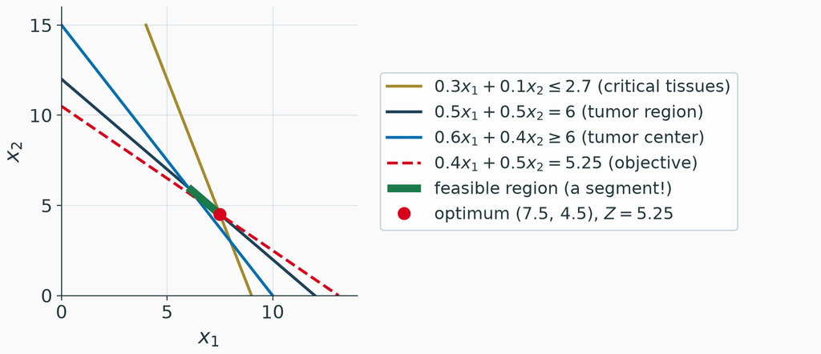

## Two Model Shapes, One Toolbox

**Resource allocation (Wyndor)**

- Maximize profit
- $\le$ constraints: do not exceed capacity
- Question: how much of each activity?

**Cost-benefit tradeoff (therapy)**

- Minimize cost
- $\ge$/$=$ constraints: meet requirements
- Question: cheapest way to comply?

**Takeaway**

Intensities $(7.5, 4.5)$ meet the dose requirements with $5.25$ kilorads to healthy anatomy. One LP toolbox prices doors and plans treatment.

# LP on a Spreadsheet: Excel Solver

## Why a Spreadsheet?

- Excel with the **Solver** add-in is the standard tool for small LPs, and the fastest way to get managers to trust a model
- The spreadsheet *is* the model: data cells, changing cells, output cells, one objective cell
- We build the Wyndor spreadsheet in four steps; the file `Wyndor.xlsx` is on LMS

**Vocabulary map**

Changing cells $=$ decision variables. Objective cell $=$ $Z$. Constraint rows compare hours used (formulas) with hours available (data).

## Step 1: Enter the Data

[figure not shown]

The problem data go into **data cells**; the layout mirrors the data table so the model stays readable.

## Step 2: Add the Changing Cells

[figure not shown]

**Changing cells** C12 and D12 hold the decisions $(x_1, x_2)$, here at the trial solution $(0, 0)$.

## Step 3: Write the Output Formulas

[figure not shown]

Column E computes hours used via `SUMPRODUCT`; objective cell G12 computes total profit.

## Step 4: Tell Solver the Model

[figure not shown]

Objective cell, changing cells, constraints, **Simplex LP** as the solving method, and nonnegativity checked. Solver returns $(2, 6)$.

## Your Turn

**In class, laptops open**

1. Open `Wyndor.xlsx`, rebuild the four steps, run Solver: confirm $(2, 6)$ and $36,000.
2. Open `Radiation therapy.xlsx`: minimization with $=$ and $\ge$ constraints. Confirm $(7.5, 4.5)$, $Z = 5.25$.
3. In Wyndor, raise Plant 1’s capacity from 4 to 6. Does the optimum move? Explain using the graph.

**Coming up**

In-class case: **Solid Waste Management** (handout).

# Large Models and the Modern Workflow

## Formulating Large LP Models

- Practical models: hundreds to many thousands of constraints and variables; nobody types those into a dialog box
- **Modeling languages** manage the model, separate from the data:
  - Algebraic: AMPL, GAMS, OPL, MPL, LINGO
  - Solver APIs in Python: **gurobipy**, Pyomo, PuLP
- **Solvers** do the arithmetic:
  - Commercial: Gurobi, CPLEX, Xpress (free academic licenses)
  - Open source: HiGHS, CBC/Clp, SoPlex

## Wyndor in Python: [Intro to gurobipy](https://gurobi.github.io/modeling-examples/intro_to_gurobipy/)

```python
import gurobipy as gp
from gurobipy import GRB

m  = gp.Model("wyndor")
x1 = m.addVar(name="doors")      # batches of doors/week
x2 = m.addVar(name="windows")    # batches of windows/week

m.setObjective(3*x1 + 5*x2, GRB.MAXIMIZE)
m.addConstr(  x1          <=  4, name="plant1")
m.addConstr(        2*x2  <= 12, name="plant2")
m.addConstr(3*x1 +  2*x2  <= 18, name="plant3")

m.optimize()
print(x1.X, x2.X, m.ObjVal)      # 2.0 6.0 36.0
```

Ten lines replace the whole spreadsheet build, and the same ten lines scale to thousands of variables. Runs in Google Colab; beginner notebooks at the [Gurobi Jupyter gallery](https://www.gurobi.com/jupyter_models/).

## AI-Assisted Modeling: The Course Workflow

**From words to models, with an AI assistant**

1. **State** the problem: decisions, objective, constraints, units
2. **Draft** with AI: formulation plus Excel or gurobipy code
3. **Interrogate**: units? every constraint justified? hidden assumptions?
4. **Validate** on an instance you can check by hand (Wyndor’s graph)

**Syllabus policy applies**

Cite every AI use and attach the exchange in an appendix. AI drafts fluently and errs confidently; step 4 is where the grade lives. No AI during in-class exams.

# Conclusions

## Conclusions

- Linear programming addresses two recurring problem families: **resource allocation** and **cost-benefit tradeoffs**
- The recipe: define activities, write a linear objective, write linear constraints, solve, interpret
- When a problem resists the LP mold: integer programming and nonlinear programming, both later in this course

## Summary

**Core takeaways**

- Linear objective, linear constraints, nonnegativity
- Optima sit at vertices (corners)
- Solver and gurobipy: same model

**Watch out for**

- The four assumptions, per application
- Fractional answers needing integers
- Unverified solver or AI output

**Bottom line**

Formulate precisely, solve with software, verify like a skeptic, interpret managerially.

## Questions?

Introduction to Linear Programming

MGMT 6460

# Appendix

## Appendix: References and Resources

**Treatment-plan image**  
Taheri-Kadkhoda, Z., Björk-Eriksson, T., Nill, S., Wilkens, J. J., Oelfke, U., Johansson, K.-A., Huber, P. E., and Münter, M. W. (2008). Intensity-modulated radiotherapy of nasopharyngeal carcinoma: a comparative treatment planning study of photons and protons. *Radiation Oncology*, 3, Article 4. [doi:10.1186/1748-717X-3-4](https://doi.org/10.1186/1748-717X-3-4). Figure 2, axial IMRT panel, cropped; [CC BY 2.0](https://creativecommons.org/licenses/by/2.0/), via Wikimedia Commons.

**Software resources**  
Intro to gurobipy: [gurobi.github.io/modeling-examples](https://gurobi.github.io/modeling-examples/intro_to_gurobipy/)  
Beginner notebooks: [gurobi.com/jupyter_models](https://www.gurobi.com/jupyter_models/)